# Lesson 2: Advanced Machine Learning (Ⅰ)

Unlike classic mechine learning, in which the features that machine learnS are extracted manually, artifical neural networks (ANN) can extract features from data automatically. With increase of data amount, multi-layer percetion and convolutional neural network are explored for getting good results. This section will introduce multi-layer precetion (MLP) algorithm.

## 1. Artificial neural networks

### 1.1 Brief overview of networks

Artificial neural networks (ANNs) refer to a collection of computing algorithms inspired by the structure of biological neural networks. ANNs consist of layers of interconnected nodes. They include Shallow neural network (SNN), such as multi-layer perception (MLP), and Deep neural networks (DNN). MLPs consis of a set of fully connected layers. They have the 3 types of layers: input layer, hidden layer and output layer, and use forward propagation for inputs and backpropagation for updating the weights. This network is like this:

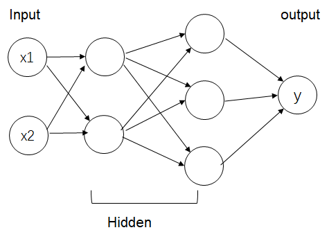

DNNs can be divided into Convolutional Neural Network (CNN), which is designed for processing grid-like data such as images, and Recurrent Neural Network (RNN), which is designed for sequential data like time series or sentences. Compared to MLP, CNNs consist of the input layer, convolution layer, pooling layer, fully connected layer, and output layer.

The architecture of RNN is different from that of MLP, and RNN is used in natural language and speech recognition by processing sequential data. RNN can process different types of data at various moments in time. Its Architecture is like this.

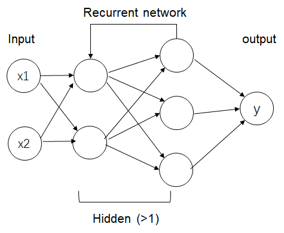

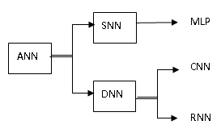

Now neural networks have been widely exploring in the field of ecology. The current applications mainly involve in the following aspects:

- **Prediction of farmland fertility**: The networks receive images from satellites like LSAT and can use this information to classify lands based on their level of cultivation. Consequently, this data can be used for making predictions about the fertility level of the grounds or developing a strategy for the optimal use of farmland.
- **Topological analysis**: Ecological researches have been addressing the stability of ecosystems using theoretical techniques. The ideas were introduced by Elton, who described a community matrix M of n × n for which the (i, j)-th entry represents the impact that a species h has on another species j around an equilibrium point of some unobserved dynamical system. This allows stability analysis from dynamical systems literature to be used, where a system is considered stable to small perturbations if the eigenvalues λ of M all have negative real parts. The study was concerned with random community matrices, but the same ideas have since been refined and applied to realistic community matrices. This area of research has been used to contribute to the ongoing debate about the relationship between biodiversity and ecosystem stability.
- **Species importance metrics**: It is often of interest to ecologists which species are the most influential within their ecosystem. These species are known as keystone species. This has consequences in conservation, since the loss of a keystone species could lead to the collapse of an entire ecosystem. Traditionally, keystone species were identified from their natural history, but it is often difficult to experimentally verify this. This has led to the introduction of graph-theoretic species importance metrics which aim to discover keystone species by considering the topology of the network.
- **Network structure prediction**: Recently, attention has turned to the problem of link prediction in the context of ecological networks. This has immediately useful practical applications in ecology. The randomness present in an ecosystem makes it unlikely that all actual interactions are observed when collecting data to construct ecological networks. Thus, the use of link prediction algorithms can help ecologists to discover actual unobserved interactions when used in conjunction with traditional ecological network construction methods.

### 1.2 R packages for networks

There are some [packages](https://subscription.packtpub.com/book/big-data-and-business-intelligence/9781788992893/1/ch01lvl1sec06/setting-up-your-r-environment) that can fit basic neural networks. For example, the **nnet** package can fit feed-forward neural networks with one hidden layer. The **neuralnet** package fits neural networks with multiple hidden layers using back-propagation. The **RSNNS** package makes many model components for training a wide variety of models. The **deepnet** package provides a number of tools for deep learning, as well as allows for different activation functions and the use of dropout for regularization.

### 1.3 Setting R env for running keras

**h2o** (https://www.h2o.ai/) is a general machine learning framework written in Java, and has an API that allows to use it from R. However, most deep learning practitioners prefer other deep learning libraries, such as **TensorFlow**, **CNTK**, and **MXNet**. **Keras** is actually a frontend abstraction for other deep learning libraries, and can use TensorFlow in the background.

**Keras** is a high-level deep learning framework that emphasizes iterative and fast development. **Keras** models can be deployed on any environment, such as a web server, iOS, Android, a browser, or the Raspberry Pi. Now using Tensorflow’s Keras is recommended over the standalone keras package.

To learn more about Keras in R, go to https://keras.rstudio.com; this link will also has more examples of R and Keras, as well as a handy Keras cheat sheet that gives a thorough reference to all of the functionality of the Keras package.

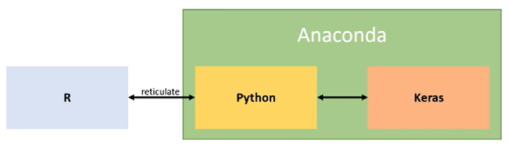

For running keras in Rstudio, we should make sure which python that we use, and create a virtual environment. Here is the code for creating a virtual python env., which is named “r-reticulate”.

```r
# library(reticulate)
# py_config() # for environment information
# install_python # for linux OS
# install_miniconda() # for win OS
```

Then we install the python packages, such as tensorflow and keras using py_install() from reticulate or use pip at the terminal in Rstudion to istall them. After that, we install the R packages of keras and tensorflow.

## 2. Building MLP models with keras

### 2.1 The MLP architechture

A Keras model is the Sequential or functional class. Here we focus on the sequential model. For more details, see [the site](https://www.kaggle.com/code/ryanholbrook/a-single-neuron)

Neural networks are composed of neurons, each of which individually performs only a simple computation (see the box1).

**Box 1: Basic knowledge of neural networks**

**Single Input**

A larger network starts with a single neuron model as a baseline. For example, in the dataset of cereals, if we train a model with ‘sugars’ as input and ‘calories’ as output, we can build a single neuron model (linear model) like this.

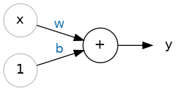

The formula for this neuron would be $y=wx+b$

**Multiple Inputs**

If we include things like ‘fiber’ or ‘protein’ content, we can just add more input connections to the neuron, and multiply each input to its connection weight and then add them all together like this.

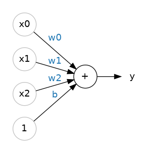

The formula for this neuron would be $y=w_{0}x_{0}+w_{1}x_{1}+w_{2}x_{2}+b$.

We can define the sequential model for allowing a neural network to “learns” by modifying the weight of each feature.

```r
# Create a network with one linear unit
#model = keras.Sequential([
#    layers.Dense(units=1, input_shape=[3])
#])
```

In the layers.Dense(), the argument ‘units’ defines how many outputs. As just predicting ‘calories’, units=1. The argument input_shape tell the dimensions of inputs. Setting input_shape=[3] ensures the model to accept 3 features as input (‘sugars’, ‘fiber’, ‘protein’). This model is now ready to be fit to training data!

We can combine and modify single units to model complex relationships. Let’s see the box2 to understand how we stack layers to get complex data transformations.

**Box 2: Constructing neural networks**

**Layers**

We collect together linear units, and then get a dense layer through a common set of inputs. Each layer in a neural network performs relatively simple transformation.

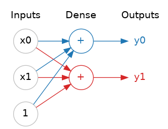

**Activation Function**

By a deep stack of layers, a network can transform its inputs in more complex ways. We stack layers inside a model, and add an activation function to each hidden layer, then a network has an ability to learn more complex (non-linear) relationships in data. Without activation functions, a network can only learn linear relationships (lines and planes). For details in activation function, see [the website](https://machinelearningmastery.com/choose-an-activation-function-for-deep-learning/).

The common activation function is the rectifier function max(0,x).

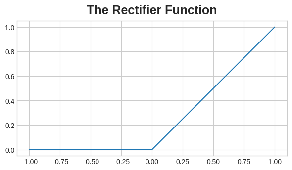

When we attach the rectifier to a linear unit, we get a rectified linear unit or ReLU. Applying a ReLU activation to a linear unit means the output becomes $max(0, w * x + b)$. For the following network, its hidden layers’ activation function is ReLU.

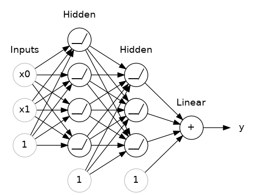

For the output layer, if it is a linear unit without activation function, that makes this network appropriate to a regression task, where we can predict some arbitrary numeric value. Other tasks (like classification) require activation function, such as softmax, on the output.

If the ‘sugar’, ‘protein’ as input, and ‘calories’ as output, by performing the following code, we will connect together a list of layers in order from first layer (input) to last layer (output), and build the regression model like above figure.

```r
#model = keras.Sequential([
    # the first hidden layer
    #   layers.Dense(units=4, activation='relu', input_shape=[2]),

    # the second hidden layer
    #   layers.Dense(units=3, activation='relu'),

    # the linear output layer
    #   layers.Dense(units=1),
##])
```

For the dataset of cereals, if we use all the 11 inputs, and add a three-layer network with over 1500 neurons, the model can be capable of learning fairly complex relationships in the data.

```r
#model = keras.Sequential([
#    layers.Dense(512, activation='relu', input_shape=[11]),
#    layers.Dense(512, activation='relu'),
#    layers.Dense(512, activation='relu'),
#    layers.Dense(1),
#])
```

### 2.2 Compiling MLP model

Training a MLP model is to adjust its weights so that it can transform the features (inputs) into the target (output). If successfully train a network, its weights must represent some relationships between those features and that target. So we need to compile networks properly to control training process in order to get training effectively and successfully (see the box3).

**Box 3: Compiling MLP networks**

**The Loss Function**

**Optimizer, minibatch and epoch**

All of the optimization algorithms used in nerual networks belong to a family called stochastic gradient descent (SGD). They are iterative algorithms that train a network in steps like this:

- Sample training data and run it to pass a network to make predictions.
- Measure the loss between the predicted values and the true values.
- Finally, adjust the weights in a direction that makes the loss smaller.

Adam is an SGD algorithm that has an adaptive learning rate that makes it suitable for most problems without any parameter tuning. Adam is a great general-purpose optimizer. RMSpro is a good one for regression problems.

Each iteration sample of training data is called minibatch or batch, while a complete round of the training data is called an epoch. The number of epochs you train is how many times the network will see each training example.

**Learning Rate and Batch Size**

The learning rate and the size of the minibatches are the two parameters that have the largest effect on how the SGD training proceeds.

After understanding these, now we can compile the sequential model with the optimizer and loss function.

```r
# for regression
# model.compile(
#    optimizer='adam',
#    loss='mae')
```

Now we’re ready to start training! We tell Keras to feed the optimizer 256 rows of the training data at a time (the batch_size) and to do that 10 times all the way through the dataset (the epochs).

```r
#history = model.fit(
#    X_train, y_train,
#    validation_data=(X_valid, y_valid),
#    batch_size=256,
#    epochs=10)
```

### 2.3 Improving MLP models

**Capacity**: A model capacity (the size and complexity of the patterns it is able to learn) is determined by its architecture, in which how many neurons it has and how the neurons are connected together. If the network is underfitting data, we should try increasing its capacity.

We can increase the capacity of a network either by making it wider (more units to layers) or by making it deeper (more layers). The wider networks have an easier time learning more linear relationships, while the deeper networks prefer more nonlinear ones. Which is better just depends on the dataset.

```r
#model = keras.Sequential([
#    layers.Dense(16, activation='relu'),
#    layers.Dense(1)])

#wider = keras.Sequential([
#    layers.Dense(32, activation='relu'),
#    layers.Dense(1)])

#deeper = keras.Sequential([
#    layers.Dense(16, activation='relu'),
#    layers.Dense(16, activation='relu'),
#    layers.Dense(1)])
```

**Early Stopping**: Keras keeps a history of the training and validation loss over the epochs. We’ll examine learning curves for evidence of underfitting and overfitting for correcting it (see the box4).

**Box 4: Improving neural networks**

**Learning Curves**

When we train a model we’ve been plotting the loss on the training set epoch by epoch. To this we’ll add a plot the validation data too. The plots we call the learning curves.

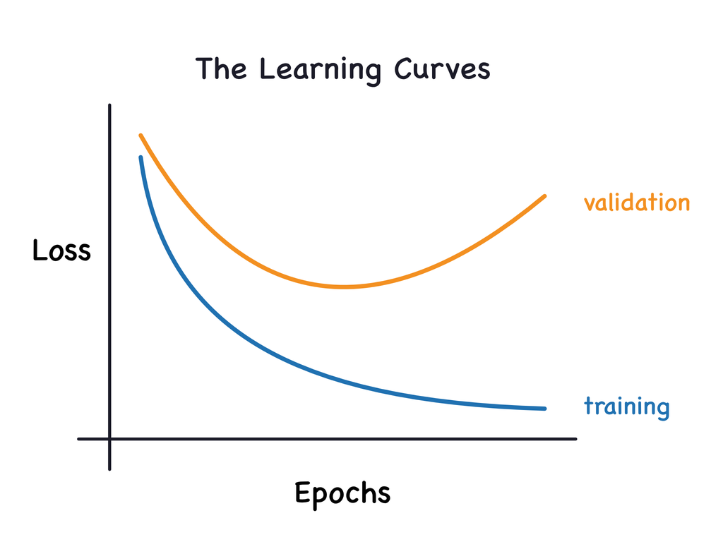

When a model learns signal both curves go down, but when it learns noise a gap is created in the curves. You should create models that minimize the size of the gap.

**Early Stopping**

When a model is too eagerly learning noise, the validation loss may start to increase during training. To prevent this, we can simply stop the training whenever it seems the validation loss isn’t decreasing anymore. Interrupting the training this way is called early stopping.

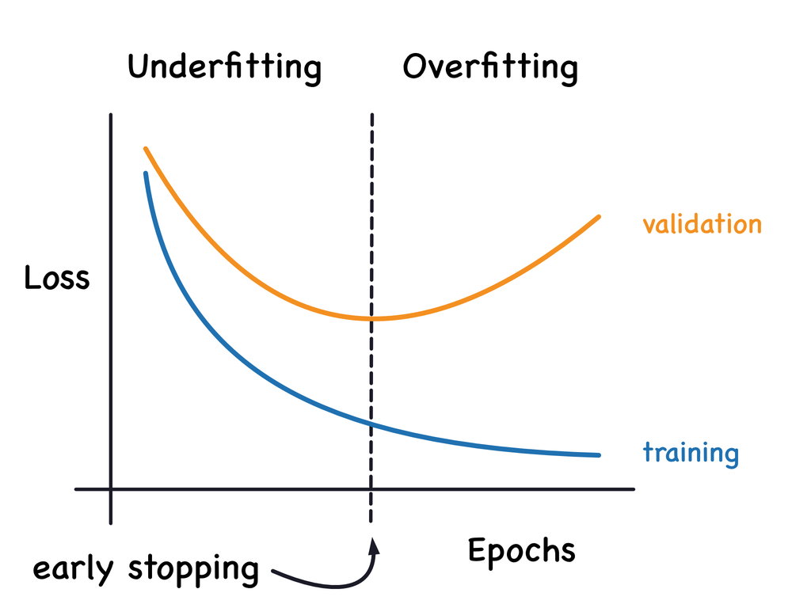

Once we detect that the validation loss is starting to rise again, we can reset the weights back to where the minimum occurred. This ensures that the model won’t continue to learn noise and overfit the data.

In Keras, we include early stopping in our training through a callback. A callback is just a function you want run every so often while the network trains. The early stopping callback will run after every epoch.

```r
#early_stopping = callbacks.EarlyStopping(
#    min_delta=0.001, # minimium amount of change to count as an improvement
#    patience=20, # how many epochs to wait before stopping
#    restore_best_weights=True,
#)
```

**Special layers**: There are some special layers that do not contain any neurons, but that they are added prevent overfitting and stabilize training. See the box5

**Box 5: Adding special layers**

**Dropout**

We randomly drop out some fraction of the input units every step of training, making it much harder for the network to learn those spurious patterns in the training data. Instead, it has to search for broad, general patterns, whose weight patterns tend to be more robust.

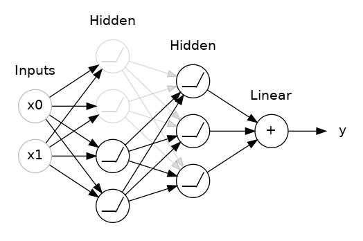

**Batch Normalization**

It’s a good idea to put all data on a common scale. The special layer, such as the batch normalization layer, can do this. It first normalizes the batch with its own mean and standard deviation, and then put the data on a new scale with two trainable rescaling parameters. A batch normalization can correct training that is slow or unstable.

In Keras, the dropout rate argument rate defines what percentage of the input units to shut off. Put the Dropout layer just before the layer you want the dropout applied to.

```r
#keras.Sequential([
#    # ...
#    layers.Dropout(rate=0.3), # apply 30% dropout to the next layer
#    layers.Dense(16),
#    # ...
#])
```

As for batch normalization layers, you can put it after a layer…

```r
#layers.Dense(16, activation='relu'),
#layers.BatchNormalization(),
```

… or between a layer and its activation function:

```r
#layers.Dense(16),
#layers.BatchNormalization(),
#layers.Activation('relu'),
```

If adding it as the first layer of a network, a batch normalization layer can act as a kind of adaptive preprocessor, standing in for something like Sci-Kit Learn’s StandardScaler.

## 3. Using MLP for classification

You are suggested to visit [the site](https://rpubs.com/Nilafhiosagam/541333) or [another site](https://www.kaggle.com/code/yashgyy/deep-learning-with-r-keras-iris-dataset).

We first check the R environment setting to ensure that our Rstudio correctly runs in a virtural environment.

```r
# rm(list = ls())
# install.packages("reticulate")
# reticulate::py_config()
# reticulate::py_install(c('tensorflow-gpu==2.2','tensorflow-addons'), pip = TRUE)
# library(keras)
```

### 3.1 Loading and processing data

We use the R’s build-in iris dataset as an example to illustrate the process of building MLP. So we load the data and do some pre-process.

```r
# library(tidyverse)
# library(datasets)
# data(iris)
```

The keras package works with a matrix, which elements are the same type, while the targets are factors, the rest is numeric. Use as.numeric() to convert the data to numbers

```r
# iris[,5] <- as.numeric(iris[,5]) -1 # Transfer the target into numbers, and all -1 for 0, 1, and 2
# iris <- as.matrix(iris) # Turn `iris` into a matrix
# dimnames(iris) <- NULL # Set iris `dimnames` to `NULL`, that is, just a matrix
```

The data are then split into training and test sets by running the following code.

```r
set.seed(1234)
ind <- sample(2, nrow(iris), replace=TRUE, prob=c(0.7, 0.3)) #  "2" means to split into two sets of train (1) and test (2), sample with replacement

xtrain <- iris[ind==1, 1:4] # Split the features
xtest <- iris[ind==2, 1:4]
ytrain <- iris[ind==1, 5] # Split the targets
ytest <- iris[ind==2, 5]
```

For multi-class classification with MLP, transforming the targets from vector value (0,1,2) to matrix with a boolean for each class.

```r
# trainLabels <- to_categorical(ytrain) # One hot encode training targets
# testLabels <- to_categorical(ytest)
# print(testLabels) # check the result
```

### 3.2 Building and tuning MLP

#### 3.2.1 Creating MLP model

Initializing a sequential model that is fully connected, with an activation functions.

```r
# model <- keras_model_sequential() # Initializing a sequential model
# model %>% # Add layers to the model: 4 columns
#   layer_dense(units = 8, activation = 'relu', input_shape = c(4)) %>%
#   layer_dense(units = 3, activation = 'softmax')
# summary(model)
```

With two arguments of optimizer and loss, compiling and fitting the model to training data.

```r
# model %>% compile( # Compile the model
#   loss = 'categorical_crossentropy', # for binary classes
#   optimizer = 'adam', # for regression using RMSprop
#   metrics = 'accuracy' #  for regression using MSE.
# )
# history <- model %>% fit( # Store the fitting history in `history`
#   xtrain,
#   trainLabels,
#   epochs = 200,
#   batch_size = 5,
#   validation_split = 0.2
# )
#
# plot(history) # Plot the history
```

#### 3.2.2 Evaluating MLP model

Visualizing the training history to make two separate, one for the model loss and another for its model accuracy

```r
# plot(history$metrics$loss, # the loss of the training data
#      main="Model Loss", xlab = "epoch",
#      ylab="loss", col="blue", type="l")
# lines(history$metrics$val_loss, # the loss of the validation data
#      col="green")
# legend("topright", c("train","test"), col=c("blue", "green"), lty=c(1,1))
#
# plot(history$metrics$acc, main="Model Accuracy", xlab = "epoch", ylab="accuracy", col="blue", type="l")
# lines(history$metrics$val_acc, col="green")
# legend("bottomright", c("train","test"), col=c("blue", "green"), lty=c(1,1))
```

#### 3.2.3 Predicting with test data

Using the MLP to predict the labels for the test set. As for the multi-class classification with softmax, model %>% predict(x) %>% k_argmax(). For binary classification with sigmoid, model %>% predict(x) %>% >(0.5) %>% k_cast(“int32”).

```r
# classes <- model %>%
#   predict(xtest, batch_size = 28) %>%
#   k_argmax() # getting the max possibility of a specific class
# table(ytest, as.vector(classes)) # Confusion matrix
# score <- model %>% evaluate(xtest, testLabels, batch_size = 128)
# print(score) # Print the score
```

#### 3.2.4 Fine-tuning MLP model

Adjusting the number of layers and hidden units as well as the number of epochs or the batch size to improve the model.

```r
# model2 <- keras_model_sequential() # Initialize the sequential model
# model2 %>% # Adding layers to model
#   layer_dense(units = 8, activation = 'relu', input_shape = c(4)) %>%
#   layer_dense(units = 5, activation = 'relu') %>%
#   layer_dense(units = 3, activation = 'softmax')
#
# model2 %>% compile(# Compile the model
#   loss = 'categorical_crossentropy',
#   optimizer = 'adam',
#   metrics = 'accuracy'
# )
#
# model2 %>% fit(# Fit the model to the data
#   xtrain, trainLabels,
#   epochs = 200, batch_size = 5,
#   validation_split = 0.2
# )
#
# score2 <- model2 %>%
#   evaluate(xtest, testLabels, batch_size = 128) # Evaluate the model
# print(score2) # Print the score
```

By reducing or adding hidden units to model for improving the model, like this.

```r
# model3 <- keras_model_sequential() # Initialize a sequential model
# model3 %>% # Add layers to model
#   layer_dense(units = 28, activation = 'relu', input_shape = c(4)) %>%
#   layer_dense(units = 3, activation = 'softmax')
#
# model3 %>% compile(# Compile the model
#   loss = 'categorical_crossentropy',
#   optimizer = 'adam',
#   metrics = 'accuracy'
# )
#
# model3 %>% fit(# Fit the model to the data
#   xtrain, trainLabels,
#   epochs = 200, batch_size = 5,
#   validation_split = 0.2
# )
#
# score3 <- model3 %>%
#   evaluate(xtest, testLabels, batch_size = 128) # Evaluate the model
#
# print(score3) # Print the score
```

### 3.3 Saving the best MLP

You can save and reload the model, and even deploy them on other platforms

```r
# save_model_hdf5(model, "results/my_model.h5")
# model <- load_model_hdf5("results/my_model.h5")
```

## 4. Using MLP for regression

Building a regression model using deep learning algorithm, please refer to [the site](https://tensorflow.rstudio.com/tutorials/keras/regression). We first check R env for correctly running keras.

```r
# rm(list = ls())
# library(tensorflow) # loading the the four packages
# library(keras)
# library(tidyverse)
# library(tidymodels)
```

### 4.1 Loading and processing data

Loading the data from a website and then clearing them for further analysis.

```r
# url <- "http://archive.ics.uci.edu/ml/machine-learning-databases/auto-mpg/auto-mpg.data"
# col_names <- c("mpg","cylinders","displacement","horsepower","weight",
#                "acceleration","model_year", "origin","car_name")
# raw_dataset <- read.table(
#   url,
#   header = T,
#   col.names = col_names,
#   na.strings = "?")
#
# dataset <- raw_dataset %>%
#           select(-car_name)
#
# # cleaning the data
# lapply(dataset, function(x) sum(is.na(x))) %>%
#       str() # Drop those rows with NA
# dataset <- na.omit(dataset)
#
# dataset <- recipe(mpg ~ ., dataset) %>%  # one-hot encode for the original column
#   step_num2factor(origin, levels = c("USA", "Europe", "Japan")) %>%
#   step_dummy(origin, one_hot = TRUE) %>% # using step_dummy(one_hot = FALSE) for binary
#   prep() %>% # update the recipe
#   bake(new_data = NULL) # view Processing data
#
# glimpse(dataset)
```

Splitting the data into training and test sets, and separating features from labels. Using train set for building model and test set for evaluation of model.

```r
# split <- initial_split(dataset, 0.8)
# train_dataset <- training(split)
# test_dataset <- testing(split)
```

Reviewing the distribution of a few pairs of columns from the training set, then may normalize the features and do some conversion of targets. There are lots of things that should be considered.

```r
# train_dataset %>%
#   select(mpg, cylinders, displacement, weight) %>%
#   GGally::ggpairs() # help identifying the correlations among variables
#
# skimr::skim(train_dataset) # Note each feature covers a very different range
#
# # Split features from labels and normalizing feature values of train set
# train_features <- train_dataset %>% select(-mpg)
# test_features <- test_dataset %>% select(-mpg)
#
# train_labels <- train_dataset %>% select(mpg)
# test_labels <- test_dataset %>% select(mpg)
#
# # see the different of each feature range and possibly skipping the step
# # my_skim <- skimr::skim_with(numeric = skimr::sfl(mean, sd)) # self-defining summary
# # train_dataset %>%
# #   select(where(~is.numeric(.x))) %>%
# #   pivot_longer(
# #     cols = everything(), names_to = "variable", values_to = "values") %>%
# #   group_by(variable) %>%
# #   summarise(mean = mean(values), sd = sd(values))
#
# normalizer <- layer_normalization(axis = -1L) # feature values transferred to the range [0,1]
# normalizer %>% adapt(as.matrix(train_features))
# print(normalizer$mean)
#
# # first <- as.matrix(train_features[1,])
# # cat('First example:', first)
# # cat('Normalized:', as.matrix(normalizer(first)))

# # Normalizing the 'horsepower' input feature
# horsepower <- matrix(train_features$horsepower) # creating a matrix of the feature
# horsepower_normalizer <- layer_normalization(input_shape = shape(1), axis = NULL)
# horsepower_normalizer %>% adapt(horsepower)
```

### 4.2 Building and evaluating MLP

First, building a linear regression between ‘mpg’ and ‘horsepower’, i.e., for 1 output.

```r
# horsepower_model <- keras_model_sequential() %>%
#   horsepower_normalizer() %>%
#   layer_dense(units = 1)
# # summary(horsepower_model)
# # Using the untrained model on the first 10 ‘horsepower’ values
# # predict(horsepower_model, horsepower[1:10,])

# Configuring the training procedure with keras's compile().
# horsepower_model %>% compile(
#   optimizer = RMSprop(),
#   loss = 'mean_absolute_error' # to be optimized
# )

# Executing to train a model for 100 epochs
# history <- horsepower_model %>% fit(
#   as.matrix(train_features$horsepower),
#   as.matrix(train_labels),
#   epochs = 100,
#   verbose = 0, # Suppress logging
#   validation_split = 0.2 # validation on 20% of the training data
# )
# plot(history) # Visualizing the model’s training progress

# Collecting the results on the test set
# test_results <- list()
# test_results[["horsepower_model"]] <- horsepower_model %>% evaluate(
#   as.matrix(test_features$horsepower),
#   as.matrix(test_labels),
#   verbose = 0
# )
# test_results
```

Second, building a linear regression with multiple inputs

```r
# # Constructing a linear regression Model
# linear_model <- keras_model_sequential() %>%
#   normalizer() %>%
#   layer_dense(units = 1)

# summary(horsepower_model)
# Using the untrained model on the first 10 ‘horsepower’ values
# predict(linear_model, as.matrix(train_features[1:10, ]))
# linear_model$layers[[2]]$kernel

# # configuring the training procedure
# linear_model %>% compile(
#   optimizer = RMSprop(),
#   loss = 'mean_absolute_error'
# )

# # executing to train a model for 100 epochs
# history <- linear_model %>% fit(
#   as.matrix(train_features),
#   as.matrix(train_labels),
#   epochs = 100,
#   verbose = 0,
#   validation_split = 0.2
# )

# # Visualizing the model’s training progress
# plot(history)
#
# # Collecting the results on the test set
# test_results[['linear_model']] <- linear_model %>%
#   evaluate(
#     as.matrix(test_features),
#     as.matrix(test_labels),
#     verbose = 0
#   )
```

Third, building a deep neural network regression with a single input

```r
# # Normalizing the 'horsepower' input feature
# horsepower <- matrix(train_features$horsepower) # creating a matrix of the feature
# horsepower_normalizer <- layer_normalization(input_shape = shape(1), axis = NULL)
# horsepower_normalizer %>% adapt(horsepower)
#
# # Constructing a linear regression Model for 1 output
# dnn_horsepower_model <- keras_model_sequential() %>%
#   horsepower_normalizer() %>%
#   layer_dense(64, activation = 'relu') %>%
#   layer_dense(64, activation = 'relu') %>%
#   layer_dense(1)
#
# # configuring the training procedure with keras's compile()
# dnn_horsepower_model %>% compile(
#   optimizer = optimizer_adam(learning_rate = 0.1),
#   loss = 'mean_absolute_error' # to be optimized
# )
#
# # executing to train a model for 100 epochs
# history <- dnn_horsepower_model %>% fit(
#   as.matrix(train_features$horsepower),
#   as.matrix(train_labels),
#   epochs = 100,
#   verbose = 0,
#   validation_split = 0.2
# )
#
# # Visualizing the model’s training progress
# plot(history)
#
# # Collecting the results on the test set
# test_results[["dnn_horsepower_model"]] <- dnn_horsepower_model %>% evaluate(
#   as.matrix(test_features$horsepower),
#   as.matrix(test_labels),
#   verbose = 0
# )
```

Forth, building a deep neural network regression with multiple inputs

```r
# # Normalizing the input features
# # normalizer <- layer_normalization(axis = -1L) # feature values transferred to the range [0,1]
# # normalizer %>% adapt(as.matrix(train_features))
#
# # Constructing a linear regression Model
# dnn_model <- keras_model_sequential() %>%
#   normalizer() %>%
#   layer_dense(64, activation = 'relu') %>%
#   layer_dense(64, activation = 'relu') %>%
#   layer_dense(1)
#
# # configuring the training procedure
# dnn_model %>% compile(
#   optimizer = optimizer_adam(learning_rate = 0.1),
#   loss = 'mean_absolute_error'
# )
#
# # executing to train a model for 100 epochs
# history <- dnn_model %>% fit(
#   as.matrix(train_features),
#   as.matrix(train_labels),
#   epochs = 100,
#   verbose = 0,
#   validation_split = 0.2
# )
# # Visualizing the model’s training progress
# plot(history)
#
# # Collecting the results on the test set
# test_results[['dnn_model']] <- dnn_model %>%
#   evaluate(
#     as.matrix(test_features),
#     as.matrix(test_labels),
#     verbose = 0
#   )
#
# sapply(test_results, function(x) x)
```

### 4.3 Predicting and saving model

```r
# # make prediction on the test set
# test_predictions <- predict(dnn_model, as.matrix(test_features))
# ggplot(data.frame(pred = as.numeric(test_predictions), mpg = test_labels$mpg)) +
#   geom_point(aes(x = pred, y = mpg)) +
#   geom_abline(intercept = 0, slope = 1, color = "blue")
#
# # check the error distribution
# qplot(test_predictions - test_labels$mpg, geom = "density")
# error <- test_predictions - test_labels
# save_model_tf(dnn_model, 'results/dnn_model1.h5')
# reloaded <- load_model_tf('results/dnn_model1')
#
# test_results[['reloaded']] <- reloaded %>% evaluate(
#   as.matrix(test_features),
#   as.matrix(test_labels),
#   verbose = 0
# )
```